# Lokesh country specific analysis

Lokesh

Lokesh Mano** • 05-Mar-2021

I am working here with processed data from Katja. Meaning that the counts I get here are already filtered using a specific function that filters out low count genes: `FilterbyExpresseion()` or something similar is the name of the function.

# 1 Reading in files

```r
tdb_fam <- read.csv("../data/dataTDB/TDB_EZfam/TDB_EZfam_filt.counts.tsv", sep = "\t", header = T, row.names = 1)
tdb_acc <- read.csv("../data/dataTDB/TDB_EZacc/TDB_EZacc_filt.counts.tsv", sep = "\t", header = T, row.names = 1)
uniref <- read.csv("../data/dataUNIREF90/uniref_filt.counts.tsv", sep = "\t", header = T, row.names = 1)
metadat <- read.csv("../data/metafile/metafile_relaxed.csv", sep = ",", header = T)
row.names(metadat) <- metadat$sample_ID
metadat$field_pair <- as.factor(metadat$field_pair)
```

# 2 Over all correction with countries

## 2.1 Family

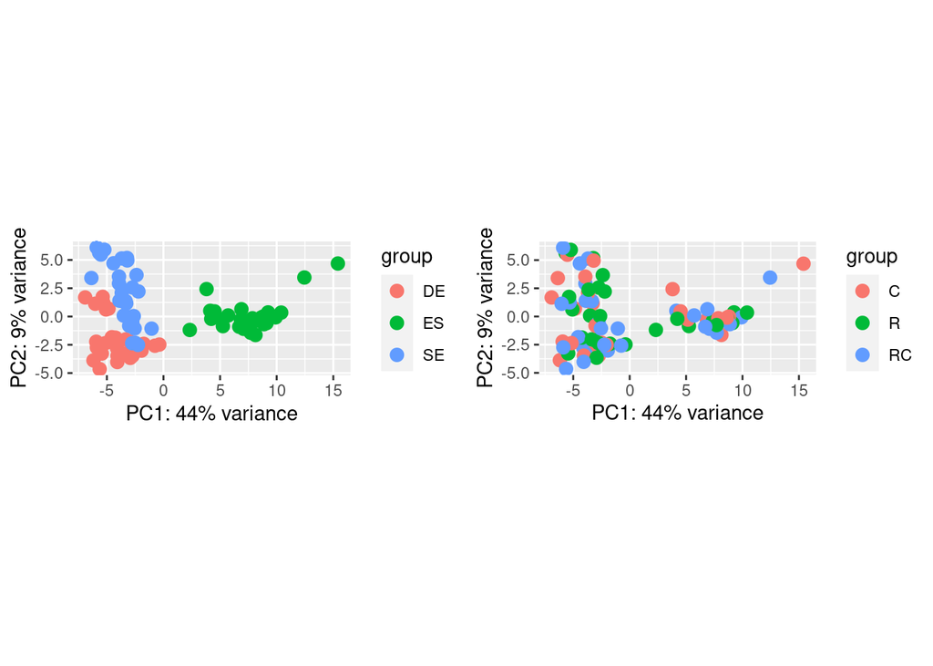

```r
library(DESeq2)
library(limma)
library(ggplot2)
library(cowplot)

dds_fam <- DESeqDataSetFromMatrix(countData = tdb_fam,
                              colData = metadat,
                              design= ~ country + treatment)

vsd_fam <- varianceStabilizingTransformation(dds_fam)

p1 <- plotPCA(vsd_fam, "country")
p2 <- plotPCA(vsd_fam, "treatment")
plot_grid(p1, p2)
```

### 2.1.1 Batch correction on countries

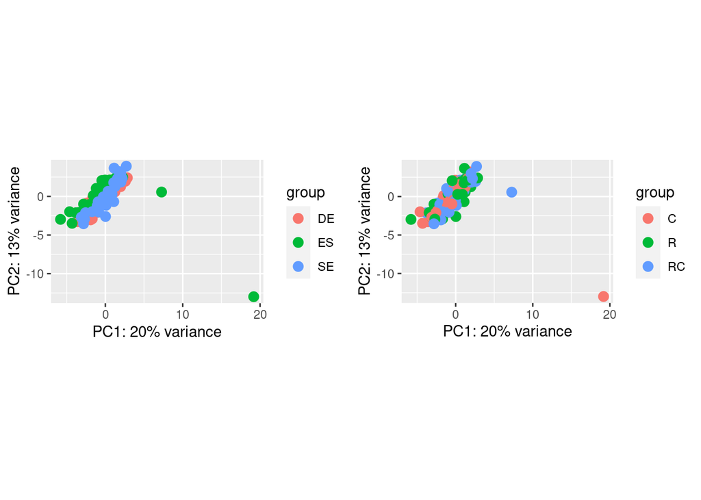

```r
vsd_fam_remCOUNTRY <- vsd_fam
assay(vsd_fam_remCOUNTRY) <- limma::removeBatchEffect(assay(vsd_fam_remCOUNTRY), vsd_fam_remCOUNTRY$country)
p1 <- plotPCA(vsd_fam_remCOUNTRY, "country")
p2 <- plotPCA(vsd_fam_remCOUNTRY, "treatment")
plot_grid(p1, p2)
```

## 2.2 Accession

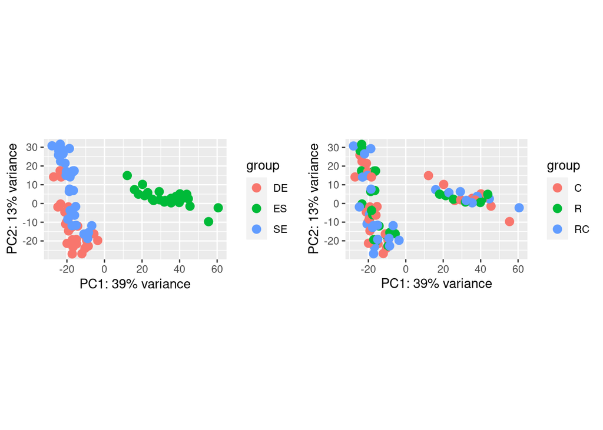

```r
dds_acc <- DESeqDataSetFromMatrix(countData = tdb_acc,
                              colData = metadat[match(colnames(tdb_acc), rownames(metadat)), ],
                              design= ~ country + treatment)

vsd_acc <- varianceStabilizingTransformation(dds_acc)

p1 <- plotPCA(vsd_acc, "country")
p2 <- plotPCA(vsd_acc, "treatment")
plot_grid(p1, p2)
```

### 2.2.1 Batch correction on countries

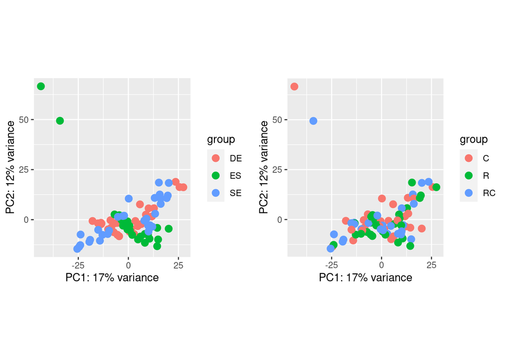

```r
vsd_acc_remCOUNTRY <- vsd_acc
assay(vsd_acc_remCOUNTRY) <- limma::removeBatchEffect(assay(vsd_acc_remCOUNTRY), vsd_acc_remCOUNTRY$country)
p1 <- plotPCA(vsd_acc_remCOUNTRY, "country")
p2 <- plotPCA(vsd_acc_remCOUNTRY, "treatment")
plot_grid(p1, p2)
```

## 2.3 UniRef

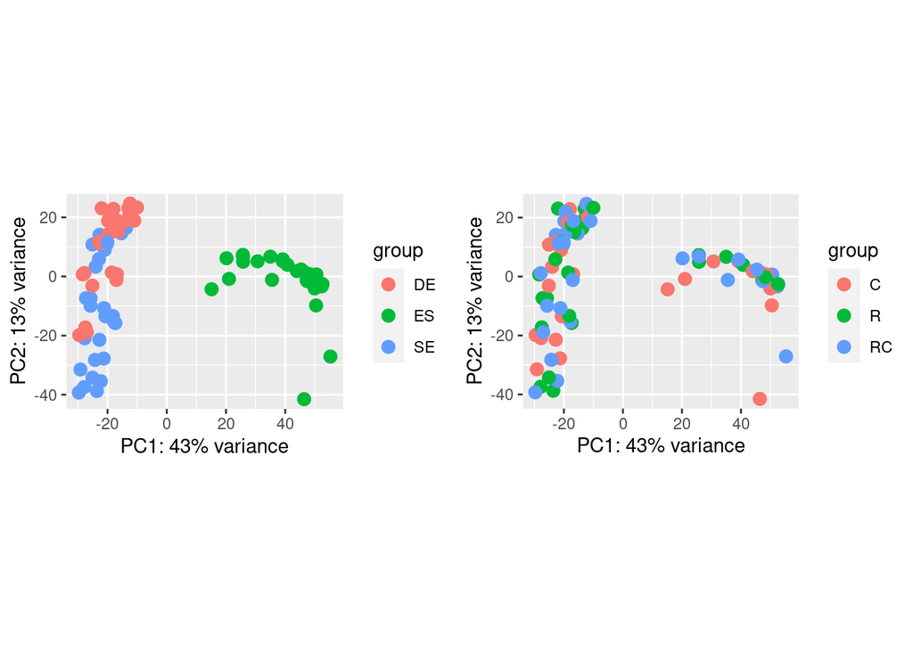

```r
dds_uni <- DESeqDataSetFromMatrix(countData = uniref,
                              colData = metadat[match(colnames(uniref), rownames(metadat)), ],
                              design= ~ country + treatment)

vsd_uni <- varianceStabilizingTransformation(dds_uni)

p1 <- plotPCA(vsd_uni, "country")
p2 <- plotPCA(vsd_uni, "treatment")
plot_grid(p1, p2)
```

### 2.3.1 Batch correction on countries

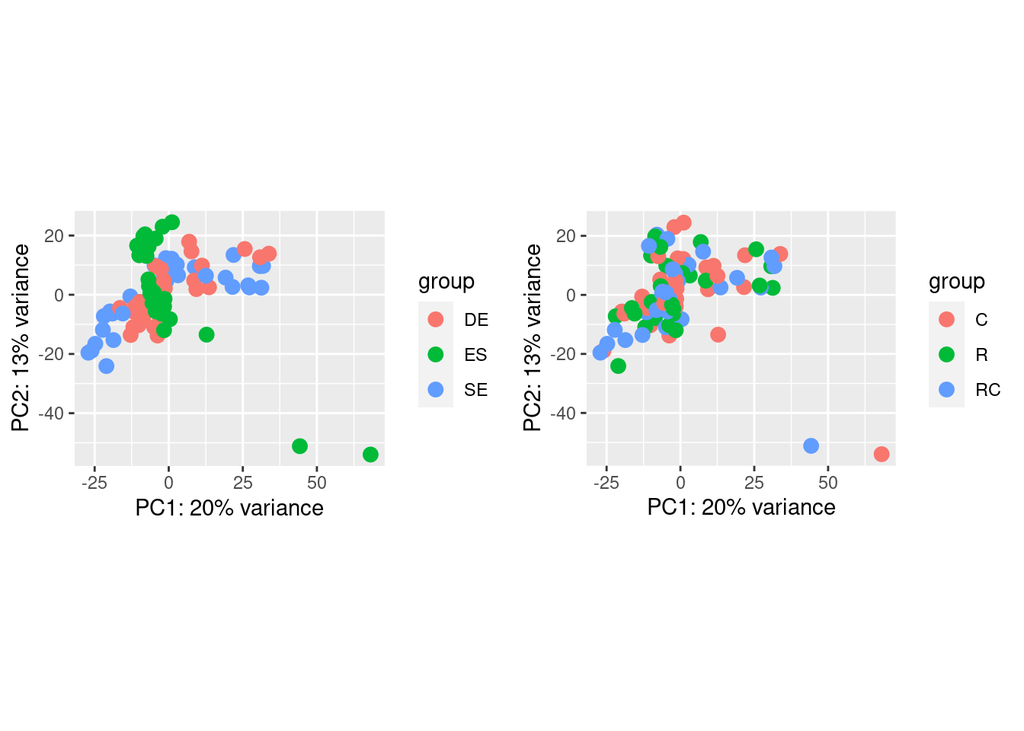

```r
vsd_uni_remCOUNTRY <- vsd_uni
assay(vsd_uni_remCOUNTRY) <- limma::removeBatchEffect(assay(vsd_uni_remCOUNTRY), vsd_uni_remCOUNTRY$country)
p1 <- plotPCA(vsd_uni_remCOUNTRY, "country")
p2 <- plotPCA(vsd_uni_remCOUNTRY, "treatment")
plot_grid(p1, p2)
```

Looks like there are 2 particular samples in Spain that is still carrying the most variance on PC1 after removing the batch effect of the country! From what I understand from the help pages: if you have design matrix for limma like: `design <- model.matrix(~0+treatment+country)` followed by `fit<-lmFit(assay,design)`. you technically tell limma that you want to consider the country as one of the driving factors. So, when you look for differential abundance, you can use `results` and `contrast` function to get exactly which variable you are after. In this case, the variation due to country is removed when you look for treatment.

In DESeq2, you specify the batch variable first in the design matrix as I have noticed ;)

# 3 Sweden

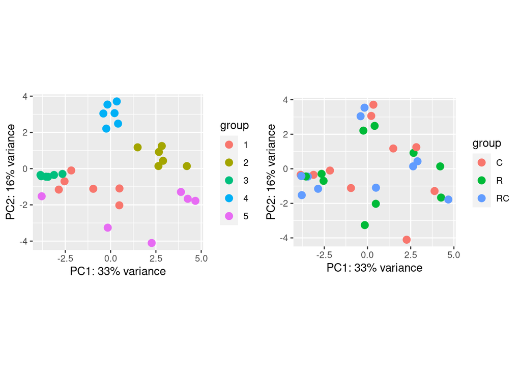

```r
library(dplyr)
library(tidyverse)

se_metadat <- metadat %>%
  filter(country == "SE")

se_tdb_fam <- tdb_fam[,colnames(tdb_fam) %in% rownames(se_metadat)]

se_dds_fam <- DESeqDataSetFromMatrix(countData = se_tdb_fam,
                              colData = se_metadat[match(colnames(se_tdb_fam), rownames(se_metadat)), ],
                              design= ~ field_pair + treatment)

se_vsd_fam <- varianceStabilizingTransformation(se_dds_fam)

p1 <- plotPCA(se_vsd_fam, "field_pair")
p2 <- plotPCA(se_vsd_fam, "treatment")
plot_grid(p1, p2)
```

### 3.0.1 Batch correction on countries

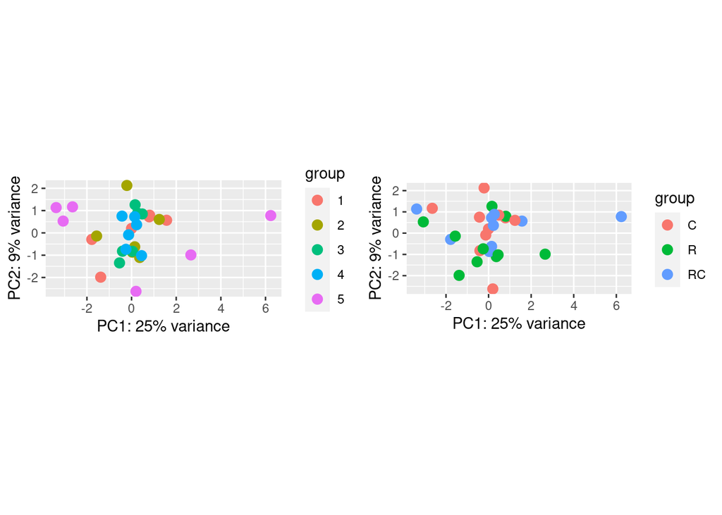

```r
se_vsd_fam_remFP <- se_vsd_fam
assay(se_vsd_fam_remFP) <- limma::removeBatchEffect(assay(se_vsd_fam_remFP), se_vsd_fam_remFP$field_pair)
p1 <- plotPCA(se_vsd_fam_remFP, "field_pair")
p2 <- plotPCA(se_vsd_fam_remFP, "treatment")
plot_grid(p1, p2)
```

## 3.1 Accession

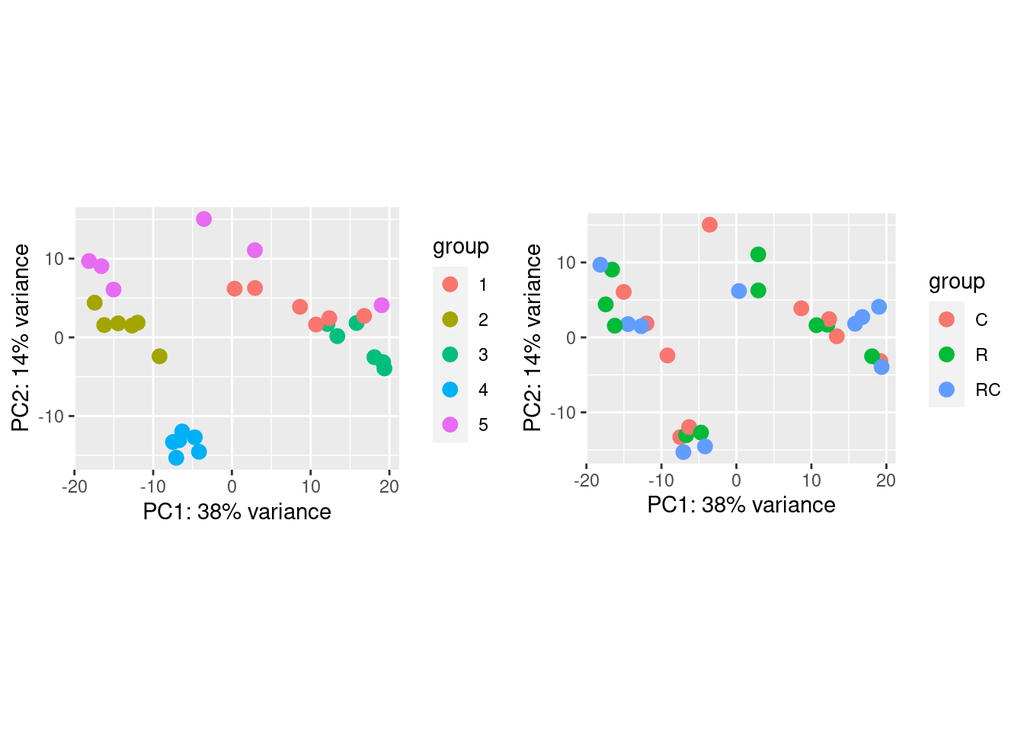

```r
se_tdb_acc <- tdb_acc[,colnames(tdb_acc) %in% rownames(se_metadat)]

se_dds_acc <- DESeqDataSetFromMatrix(countData = se_tdb_acc,
                              colData = se_metadat[match(colnames(se_tdb_acc), rownames(se_metadat)), ],
                              design= ~ field_pair + treatment)

se_vsd_acc <- varianceStabilizingTransformation(se_dds_acc)

p1 <- plotPCA(se_vsd_acc, "field_pair")
p2 <- plotPCA(se_vsd_acc, "treatment")
plot_grid(p1, p2)
```

### 3.1.1 Batch correction on countries

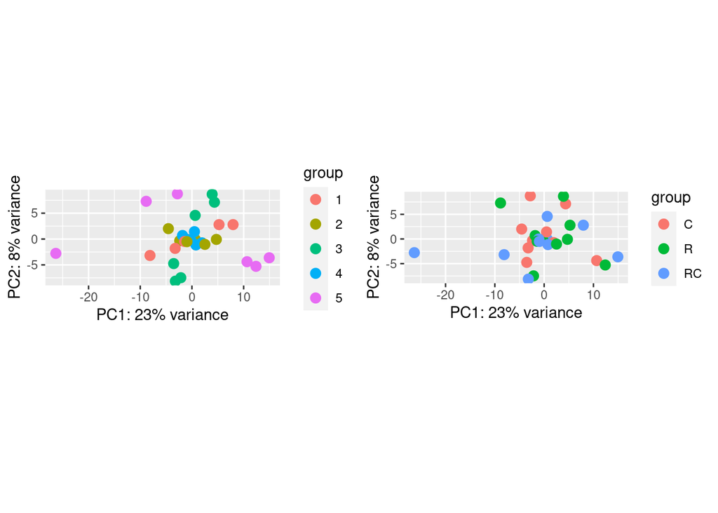

```r
se_vsd_acc_remFP <- se_vsd_acc
assay(se_vsd_acc_remFP) <- limma::removeBatchEffect(assay(se_vsd_acc_remFP), se_vsd_acc_remFP$field_pair)
p1 <- plotPCA(se_vsd_acc_remFP, "field_pair")
p2 <- plotPCA(se_vsd_acc_remFP, "treatment")
plot_grid(p1, p2)
```

## 3.2 UniRef

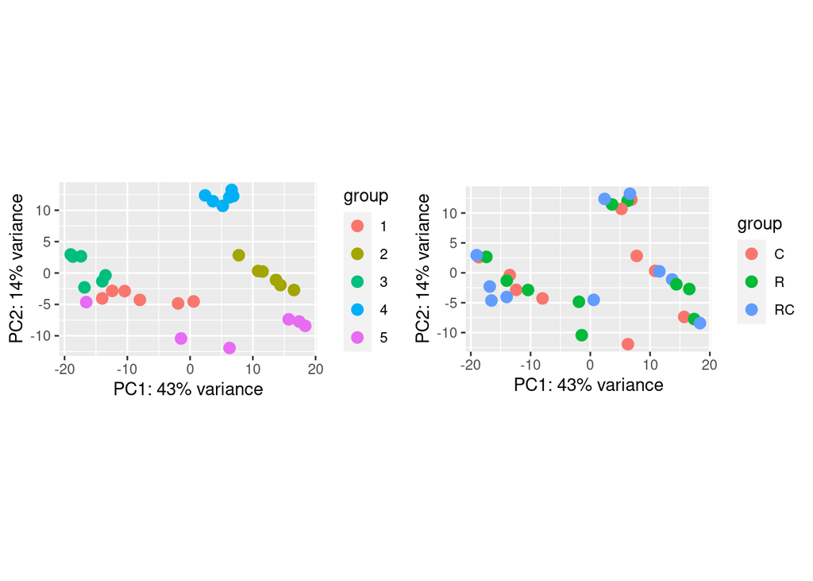

```r
se_uniref <- uniref[,colnames(uniref) %in% rownames(se_metadat)]

se_dds_uni <- DESeqDataSetFromMatrix(countData = se_uniref,
                              colData = se_metadat[match(colnames(se_uniref), rownames(se_metadat)), ],
                              design= ~ field_pair + treatment)

se_vsd_uni <- varianceStabilizingTransformation(se_dds_uni)

p1 <- plotPCA(se_vsd_uni, "field_pair")
p2 <- plotPCA(se_vsd_uni, "treatment")
plot_grid(p1, p2)
```

### 3.2.1 Batch correction on countries

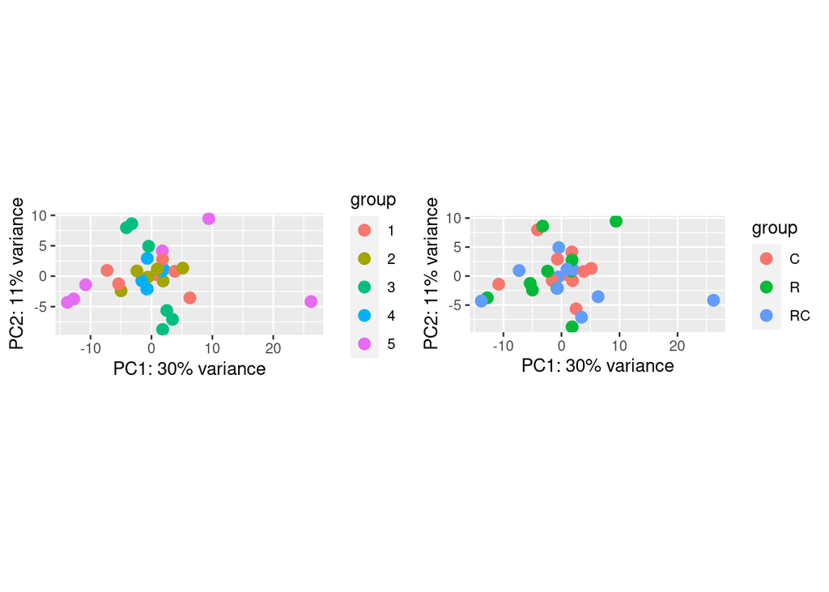

```r
se_vsd_uni_remFP <- se_vsd_uni
assay(se_vsd_uni_remFP) <- limma::removeBatchEffect(assay(se_vsd_uni_remFP), se_vsd_uni_remFP$field_pair)
p1 <- plotPCA(se_vsd_uni_remFP, "field_pair")
p2 <- plotPCA(se_vsd_uni_remFP, "treatment")
plot_grid(p1, p2)
```

# 4 Germany

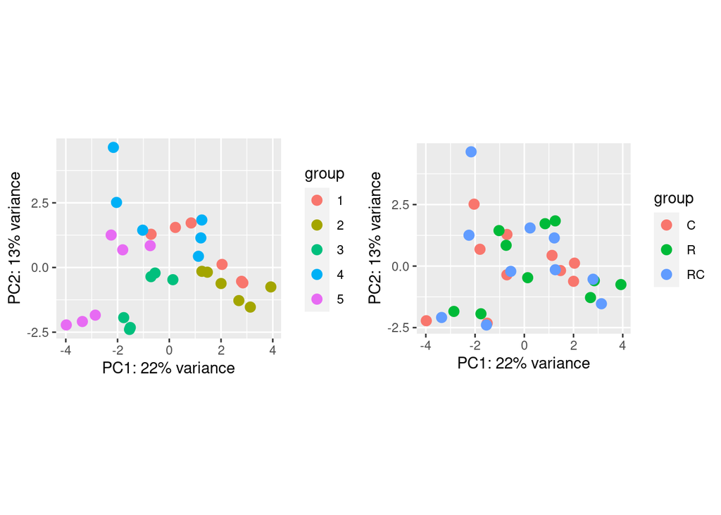

```r
de_metadat <- metadat %>%
  filter(country == "DE")

de_tdb_fam <- tdb_fam[,colnames(tdb_fam) %in% rownames(de_metadat)]

de_dds_fam <- DESeqDataSetFromMatrix(countData = de_tdb_fam,
                              colData = de_metadat[match(colnames(de_tdb_fam), rownames(de_metadat)), ],
                              design= ~ field_pair + treatment)

de_vsd_fam <- varianceStabilizingTransformation(de_dds_fam)

p1 <- plotPCA(de_vsd_fam, "field_pair")
p2 <- plotPCA(de_vsd_fam, "treatment")
plot_grid(p1, p2)
```

### 4.0.1 Batch correction on countries

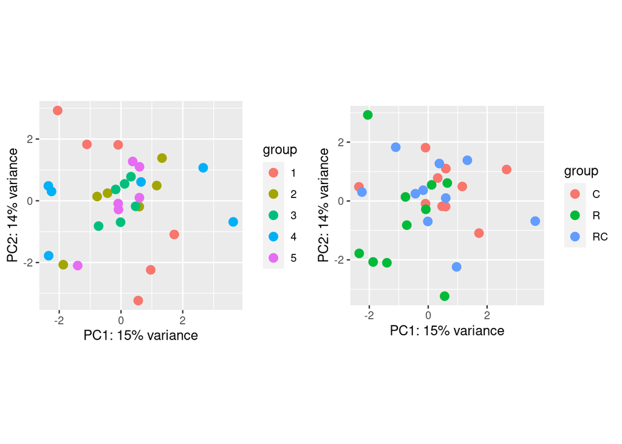

```r
de_vsd_fam_remFP <- de_vsd_fam
assay(de_vsd_fam_remFP) <- limma::removeBatchEffect(assay(de_vsd_fam_remFP), de_vsd_fam_remFP$field_pair)
p1 <- plotPCA(de_vsd_fam_remFP, "field_pair")
p2 <- plotPCA(de_vsd_fam_remFP, "treatment")
plot_grid(p1, p2)
```

## 4.1 Accession

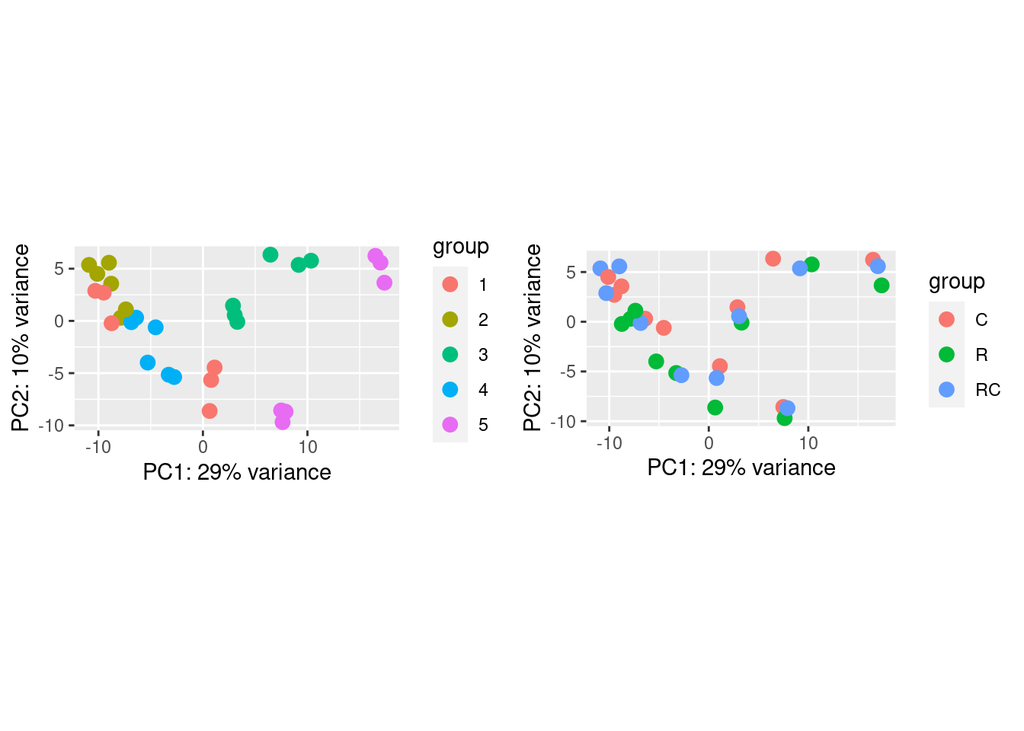

```r
de_tdb_acc <- tdb_acc[,colnames(tdb_acc) %in% rownames(de_metadat)]

de_dds_acc <- DESeqDataSetFromMatrix(countData = de_tdb_acc,
                              colData = de_metadat[match(colnames(de_tdb_acc), rownames(de_metadat)), ],
                              design= ~ field_pair + treatment)

de_vsd_acc <- varianceStabilizingTransformation(de_dds_acc)

p1 <- plotPCA(de_vsd_acc, "field_pair")
p2 <- plotPCA(de_vsd_acc, "treatment")
plot_grid(p1, p2)
```

### 4.1.1 Batch correction on countries

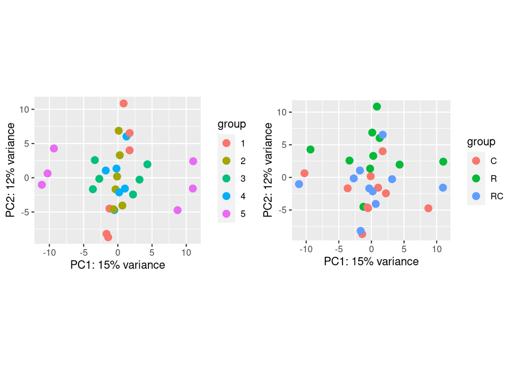

```r
de_vsd_acc_remFP <- de_vsd_acc
assay(de_vsd_acc_remFP) <- limma::removeBatchEffect(assay(de_vsd_acc_remFP), de_vsd_acc_remFP$field_pair)
p1 <- plotPCA(de_vsd_acc_remFP, "field_pair")
p2 <- plotPCA(de_vsd_acc_remFP, "treatment")
plot_grid(p1, p2)
```

## 4.2 UniRef

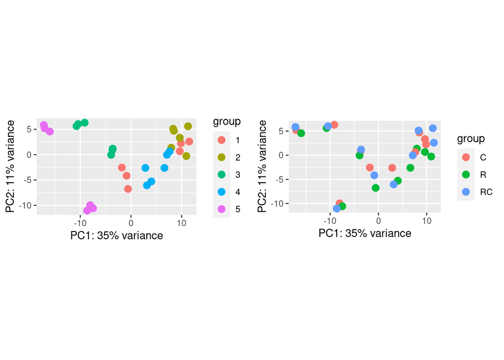

```r
de_uniref <- uniref[,colnames(uniref) %in% rownames(de_metadat)]

de_dds_uni <- DESeqDataSetFromMatrix(countData = de_uniref,
                              colData = de_metadat[match(colnames(de_uniref), rownames(de_metadat)), ],
                              design= ~ field_pair + treatment)

de_vsd_uni <- varianceStabilizingTransformation(de_dds_uni)

p1 <- plotPCA(de_vsd_uni, "field_pair")
p2 <- plotPCA(de_vsd_uni, "treatment")
plot_grid(p1, p2)
```

### 4.2.1 Batch correction on countries

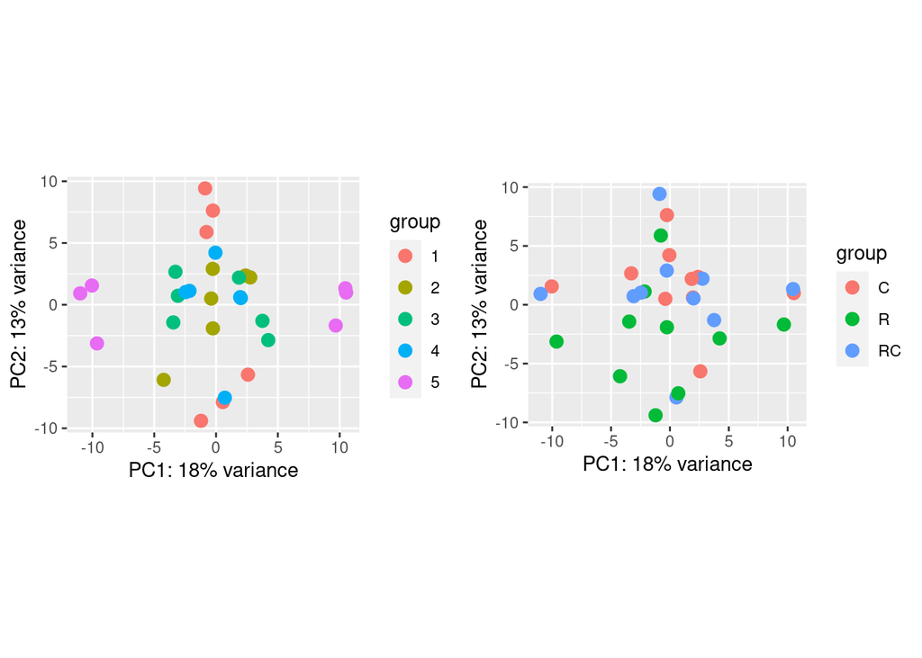

```r
de_vsd_uni_remFP <- de_vsd_uni
assay(de_vsd_uni_remFP) <- limma::removeBatchEffect(assay(de_vsd_uni_remFP), de_vsd_uni_remFP$field_pair)
p1 <- plotPCA(de_vsd_uni_remFP, "field_pair")
p2 <- plotPCA(de_vsd_uni_remFP, "treatment")
plot_grid(p1, p2)
```

# 5 Spain

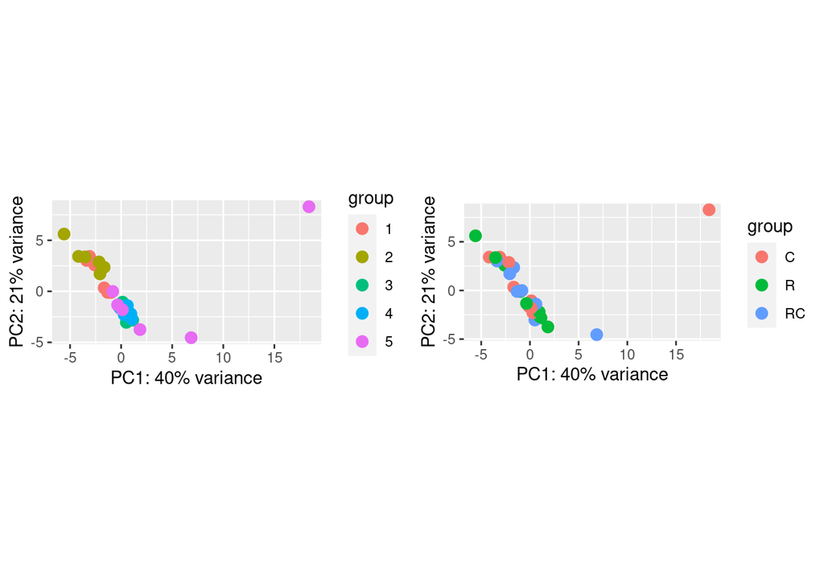

```r
es_metadat <- metadat %>%
  filter(country == "ES")

es_tdb_fam <- tdb_fam[,colnames(tdb_fam) %in% rownames(es_metadat)]

es_dds_fam <- DESeqDataSetFromMatrix(countData = es_tdb_fam,
                              colData = es_metadat[match(colnames(es_tdb_fam), rownames(es_metadat)), ],
                              design= ~ field_pair + treatment)

es_vsd_fam <- varianceStabilizingTransformation(es_dds_fam)

p1 <- plotPCA(es_vsd_fam, "field_pair")
p2 <- plotPCA(es_vsd_fam, "treatment")
plot_grid(p1, p2)
```

### 5.0.1 Batch correction on countries

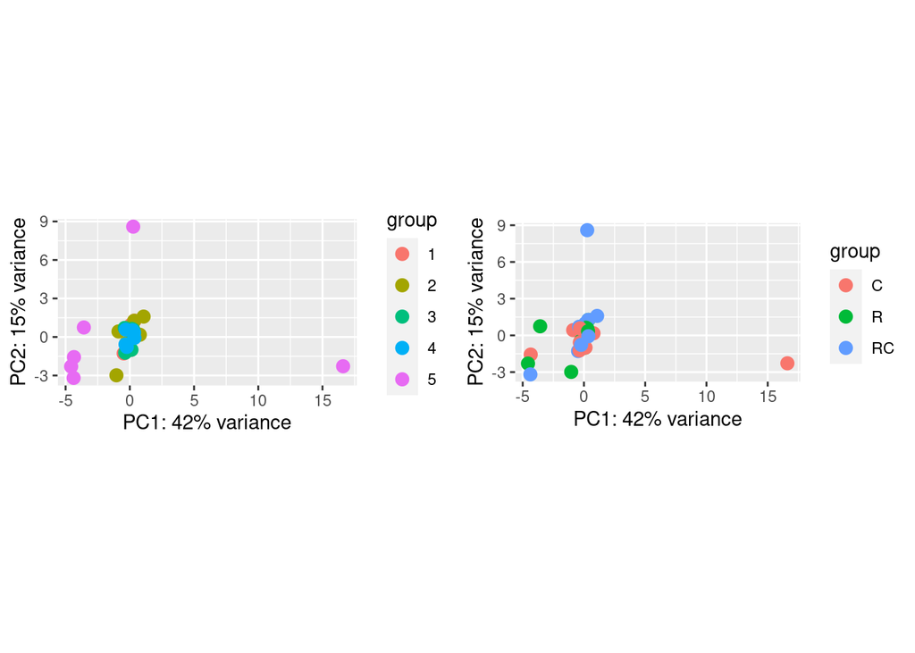

```r
es_vsd_fam_remFP <- es_vsd_fam
assay(es_vsd_fam_remFP) <- limma::removeBatchEffect(assay(es_vsd_fam_remFP), es_vsd_fam_remFP$field_pair)
p1 <- plotPCA(es_vsd_fam_remFP, "field_pair")
p2 <- plotPCA(es_vsd_fam_remFP, "treatment")
plot_grid(p1, p2)
```

## 5.1 Accession

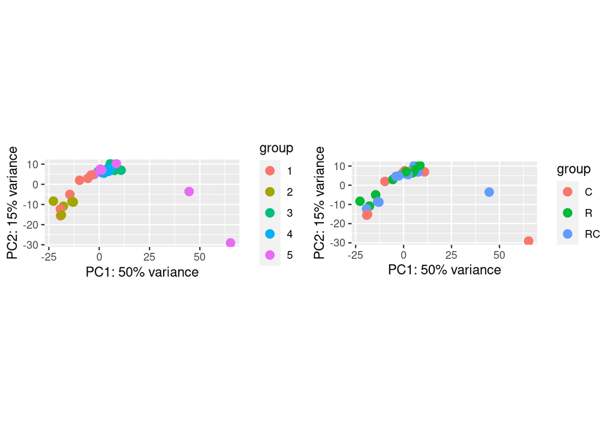

```r
es_tdb_acc <- tdb_acc[,colnames(tdb_acc) %in% rownames(es_metadat)]

es_dds_acc <- DESeqDataSetFromMatrix(countData = es_tdb_acc,
                              colData = es_metadat[match(colnames(es_tdb_acc), rownames(es_metadat)), ],
                              design= ~ field_pair + treatment)

es_vsd_acc <- varianceStabilizingTransformation(es_dds_acc)

p1 <- plotPCA(es_vsd_acc, "field_pair")
p2 <- plotPCA(es_vsd_acc, "treatment")
plot_grid(p1, p2)
```

### 5.1.1 Batch correction on countries

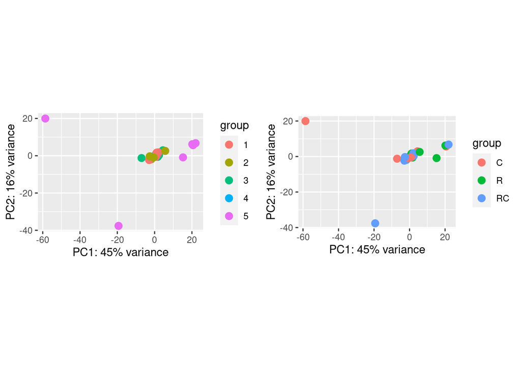

```r
es_vsd_acc_remFP <- es_vsd_acc
assay(es_vsd_acc_remFP) <- limma::removeBatchEffect(assay(es_vsd_acc_remFP), es_vsd_acc_remFP$field_pair)
p1 <- plotPCA(es_vsd_acc_remFP, "field_pair")
p2 <- plotPCA(es_vsd_acc_remFP, "treatment")
plot_grid(p1, p2)
```

## 5.2 UniRef

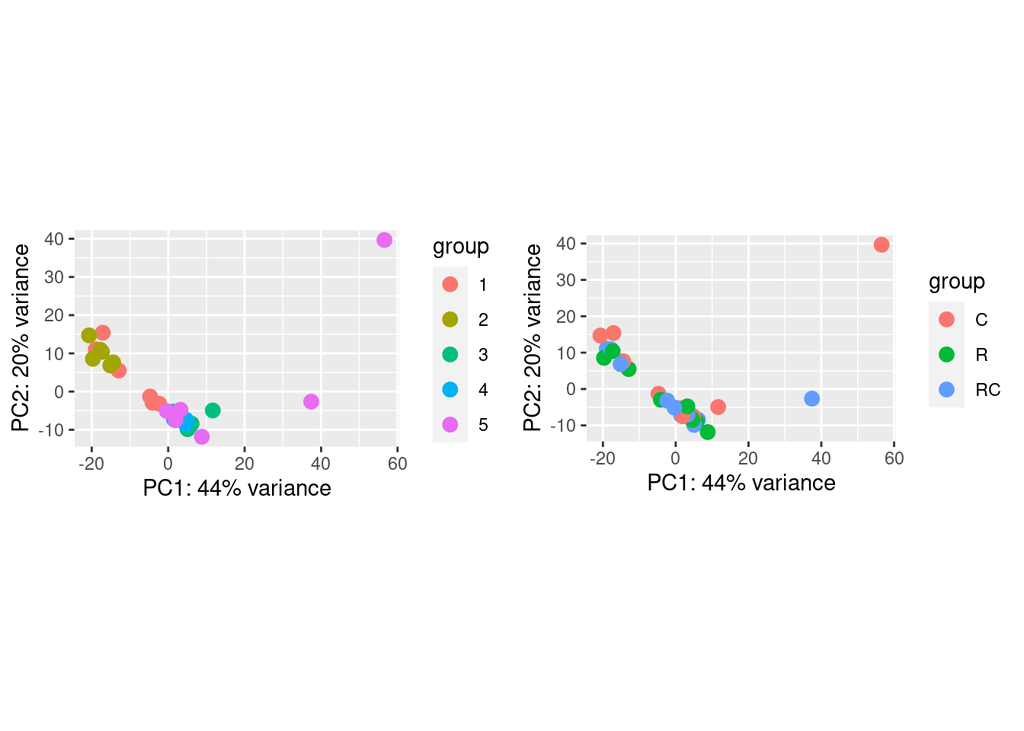

```r
es_uniref <- uniref[,colnames(uniref) %in% rownames(es_metadat)]

es_dds_uni <- DESeqDataSetFromMatrix(countData = es_uniref,
                              colData = es_metadat[match(colnames(es_uniref), rownames(es_metadat)), ],
                              design= ~ field_pair + treatment)

es_vsd_uni <- varianceStabilizingTransformation(es_dds_uni)

p1 <- plotPCA(es_vsd_uni, "field_pair")
p2 <- plotPCA(es_vsd_uni, "treatment")
plot_grid(p1, p2)
```

### 5.2.1 Batch correction on countries

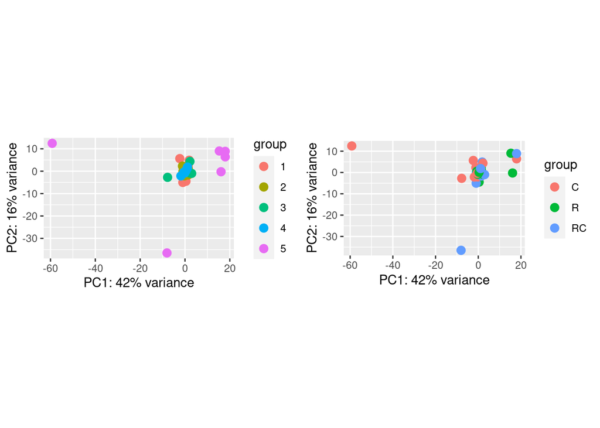

```r
es_vsd_uni_remFP <- es_vsd_uni
assay(es_vsd_uni_remFP) <- limma::removeBatchEffect(assay(es_vsd_uni_remFP), es_vsd_uni_remFP$field_pair)
p1 <- plotPCA(es_vsd_uni_remFP, "field_pair")
p2 <- plotPCA(es_vsd_uni_remFP, "treatment")
plot_grid(p1, p2)
```